# week2

김주은

2019년 3월 26일

일단 디렉토리 설정 후 파일을 읽여서 대략적인 모양을 살펴본다.

```r
setwd("C:\\Users\\Jooeun Kim\\Desktop\\ESC\\2019 SPRING\\[Week 2] Assignment\\dataset")
data <- read.csv("boston.csv",header=TRUE)
str(data)
```

```
## 'data.frame':    506 obs. of  14 variables:
##  $ crim   : num  0.00632 0.02731 0.02729 0.03237 0.06905 ...
##  $ zn     : num  18 0 0 0 0 0 12.5 12.5 12.5 12.5 ...
##  $ indus  : num  2.31 7.07 7.07 2.18 2.18 2.18 7.87 7.87 7.87 7.87 ...
##  $ chas   : int  0 0 0 0 0 0 0 0 0 0 ...
##  $ nox    : num  0.538 0.469 0.469 0.458 0.458 0.458 0.524 0.524 0.524 0.524 ...
##  $ rm     : num  6.58 6.42 7.18 7 7.15 ...
##  $ age    : num  65.2 78.9 61.1 45.8 54.2 58.7 66.6 96.1 100 85.9 ...
##  $ dis    : num  4.09 4.97 4.97 6.06 6.06 ...
##  $ rad    : int  1 2 2 3 3 3 5 5 5 5 ...
##  $ tax    : int  296 242 242 222 222 222 311 311 311 311 ...
##  $ ptratio: num  15.3 17.8 17.8 18.7 18.7 18.7 15.2 15.2 15.2 15.2 ...
##  $ black  : num  397 397 393 395 397 ...
##  $ lstat  : num  4.98 9.14 4.03 2.94 5.33 ...
##  $ medv   : num  24 21.6 34.7 33.4 36.2 28.7 22.9 27.1 16.5 18.9 ...
```

필요한 패키지를 깐다.

1. EDA

```r
summary(data)
```

```
##       crim                zn             indus            chas
##  Min.   : 0.00632   Min.   :  0.00   Min.   : 0.46   Min.   :0.00000
##  1st Qu.: 0.08204   1st Qu.:  0.00   1st Qu.: 5.19   1st Qu.:0.00000
##  Median : 0.25651   Median :  0.00   Median : 9.69   Median :0.00000
##  Mean   : 3.61352   Mean   : 11.36   Mean   :11.14   Mean   :0.06917
##  3rd Qu.: 3.67708   3rd Qu.: 12.50   3rd Qu.:18.10   3rd Qu.:0.00000
##  Max.   :88.97620   Max.   :100.00   Max.   :27.74   Max.   :1.00000
##       nox               rm             age              dis
##  Min.   :0.3850   Min.   :3.561   Min.   :  2.90   Min.   : 1.130
##  1st Qu.:0.4490   1st Qu.:5.886   1st Qu.: 45.02   1st Qu.: 2.100
##  Median :0.5380   Median :6.208   Median : 77.50   Median : 3.207
##  Mean   :0.5547   Mean   :6.285   Mean   : 68.57   Mean   : 3.795
##  3rd Qu.:0.6240   3rd Qu.:6.623   3rd Qu.: 94.08   3rd Qu.: 5.188
##  Max.   :0.8710   Max.   :8.780   Max.   :100.00   Max.   :12.127
##       rad              tax           ptratio          black
##  Min.   : 1.000   Min.   :187.0   Min.   :12.60   Min.   :  0.32
##  1st Qu.: 4.000   1st Qu.:279.0   1st Qu.:17.40   1st Qu.:375.38
##  Median : 5.000   Median :330.0   Median :19.05   Median :391.44
##  Mean   : 9.549   Mean   :408.2   Mean   :18.46   Mean   :356.67
##  3rd Qu.:24.000   3rd Qu.:666.0   3rd Qu.:20.20   3rd Qu.:396.23
##  Max.   :24.000   Max.   :711.0   Max.   :22.00   Max.   :396.90
##      lstat            medv
##  Min.   : 1.73   Min.   : 5.00
##  1st Qu.: 6.95   1st Qu.:17.02
##  Median :11.36   Median :21.20
##  Mean   :12.65   Mean   :22.53
##  3rd Qu.:16.95   3rd Qu.:25.00
##  Max.   :37.97   Max.   :50.00
```

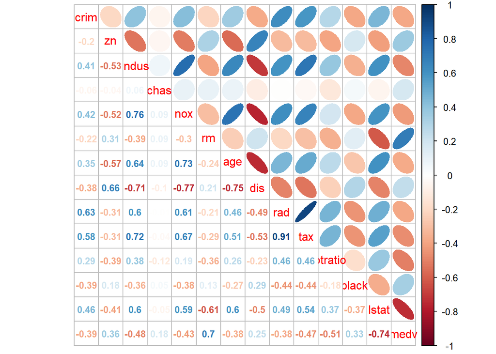

[output not shown]

```r
attach(data)
corrplot.mixed(cor(data), lower = "number", upper = "ellipse",number.cex=0.8,number.digits = 2)
```

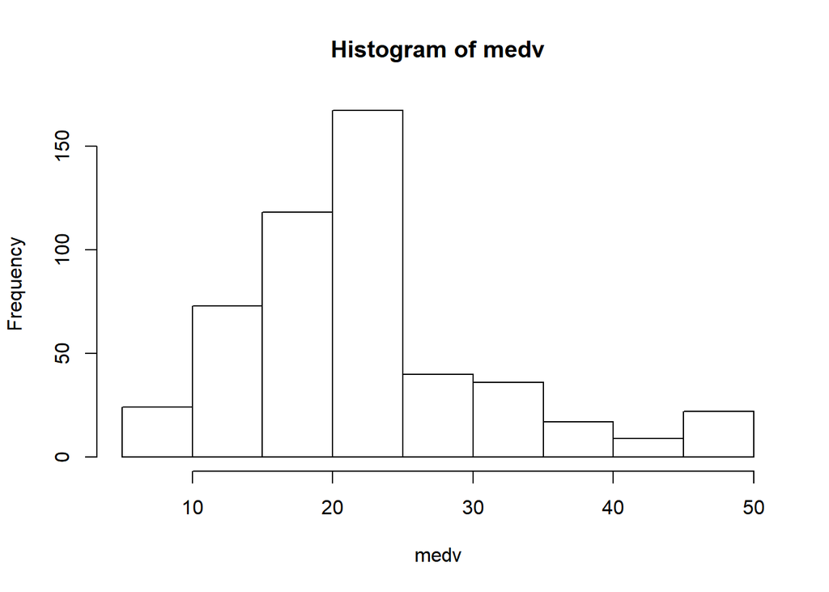

```r
hist(medv)
```

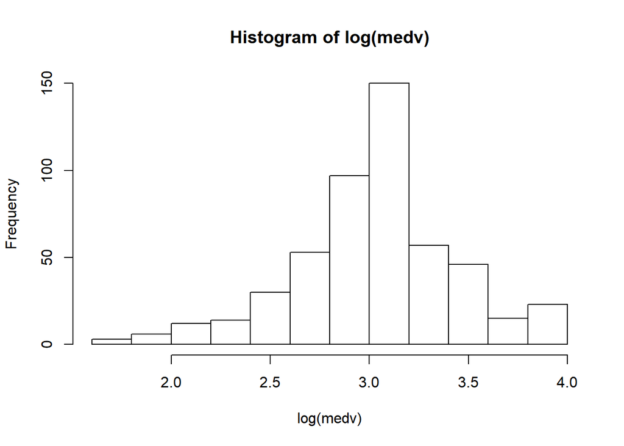

```r
hist(log(medv))
```

```r
data$medv <- log(medv)
```

```r
data1 <- data
data1$chas <- as.factor(chas)
data1$rad <- as.factor(rad)
```

2. Full Model

```r
lm.fit <- lm(medv~.,data=data1[-medv])
summary(lm.fit)
```

```
##
## Call:
## lm(formula = medv ~ ., data = data1[-medv])
##
## Residuals:
##     Min      1Q  Median      3Q     Max
## -12.805  -4.618  -1.472   2.594  32.969
##
## Coefficients:
##             Estimate Std. Error t value Pr(>|t|)
## (Intercept) 27.11280    0.84523  32.077  < 2e-16 ***
## crim        -0.22880    0.04299  -5.322 1.55e-07 ***
## zn           0.05929    0.01706   3.474 0.000557 ***
## indus       -0.44033    0.06239  -7.057 5.68e-12 ***
## chas1        6.89406    1.33266   5.173 3.33e-07 ***
## ---
## Signif. codes:  0 '***' 0.001 '**' 0.01 '*' 0.05 '.' 0.1 ' ' 1
##
## Residual standard error: 7.561 on 501 degrees of freedom
## Multiple R-squared:  0.3295, Adjusted R-squared:  0.3242
## F-statistic: 61.56 on 4 and 501 DF,  p-value: < 2.2e-16
```

13개의 설명변수 중 4개가 남았고, 모두 유의하다는 결과가 나온다. 하지만 adjuseted R^2가 매우 낮다.ㅎㅎ

```r
regfit.full <- regsubsets(medv~.,data=data,nvmax=13)
reg.summary <- summary(regfit.full)
which.min(reg.summary$bic)
```

```
## [1] 10
```

```r
coef(regfit.full,which.min(reg.summary$bic))
```

```
##   (Intercept)          crim          chas           nox            rm
##  4.1000969129 -0.0100763109  0.1049847683 -0.7515378851  0.0954515875
##           dis           rad           tax       ptratio         black
## -0.0442395227  0.0130840820 -0.0005049891 -0.0409840161  0.0004143037
##         lstat
## -0.0285881231
```

```r
regfit.fwd <- regsubsets(medv~.,data=data,nvmax=13,method="forward")
reg.summary <- summary(regfit.fwd)
which.min(reg.summary$bic)
```

```
## [1] 10
```

```r
coef(regfit.fwd,which.min(reg.summary$bic))
```

```
##   (Intercept)          crim          chas           nox            rm
##  4.1000969129 -0.0100763109  0.1049847683 -0.7515378851  0.0954515875
##           dis           rad           tax       ptratio         black
## -0.0442395227  0.0130840820 -0.0005049891 -0.0409840161  0.0004143037
##         lstat
## -0.0285881231
```

```r
regfit.bwd <- regsubsets(medv~.,data=data,nvmax=13,method="backward")
reg.summary <- summary(regfit.bwd)
which.min(reg.summary$bic)
```

```
## [1] 10
```

```r
coef(regfit.bwd,which.min(reg.summary$bic))
```

```
##   (Intercept)          crim          chas           nox            rm
##  4.1000969129 -0.0100763109  0.1049847683 -0.7515378851  0.0954515875
##           dis           rad           tax       ptratio         black
## -0.0442395227  0.0130840820 -0.0005049891 -0.0409840161  0.0004143037
##         lstat
## -0.0285881231
```

신기하게도 best subset, forward, backward selection 모두에서 똑같은 결과가 나온다.

4. Regularization ridge regression을 수행하는 함수는 `glmnet(alpha=0)`

```r
x <- as.matrix(data[-medv])
y <- as.matrix(medv)
glmnet(x=x, y=y, alpha=0) -> ridge.fit
ridge.fit
```

```
##
## Call:  glmnet(x = x, y = y, alpha = 0)
##
##        Df      %Dev    Lambda
##   [1,]  4 1.102e-36 4444.0000
##   [2,]  4 2.461e-03 4050.0000
##   [3,]  4 2.699e-03 3690.0000
##   [4,]  4 2.960e-03 3362.0000
##   [5,]  4 3.247e-03 3063.0000
##   [6,]  4 3.561e-03 2791.0000
##   [7,]  4 3.905e-03 2543.0000
##   [8,]  4 4.281e-03 2317.0000
##   [9,]  4 4.694e-03 2111.0000
##  [10,]  4 5.146e-03 1924.0000
##  [11,]  4 5.641e-03 1753.0000
```

[output cut: 89 more lines]

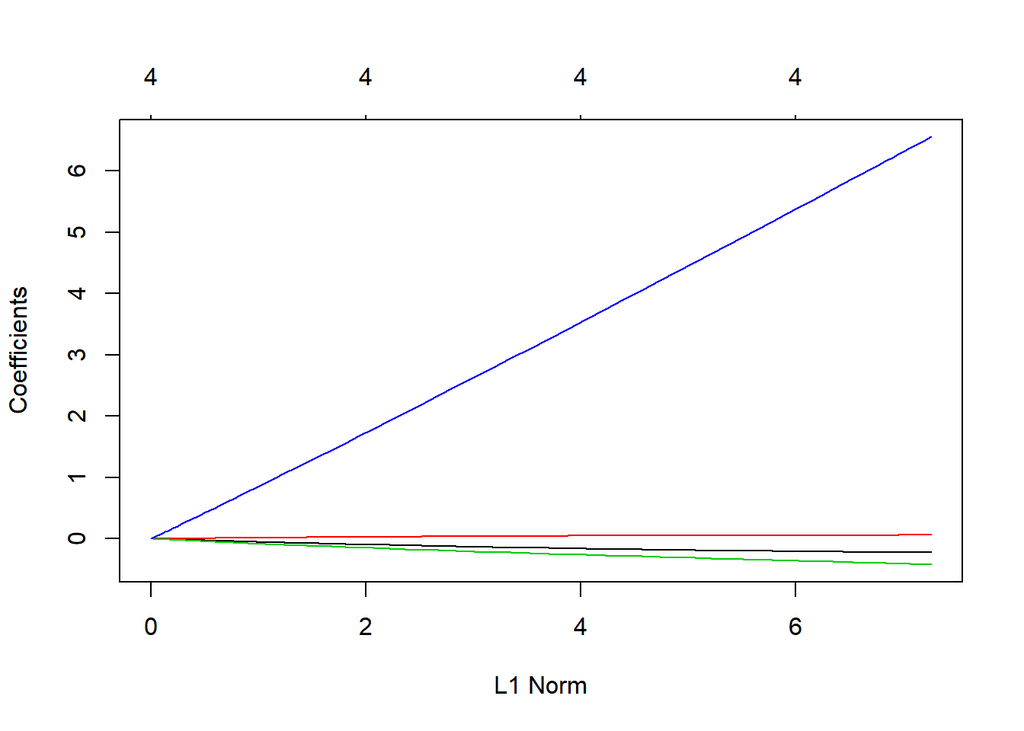

```r
plot(ridge.fit)
```

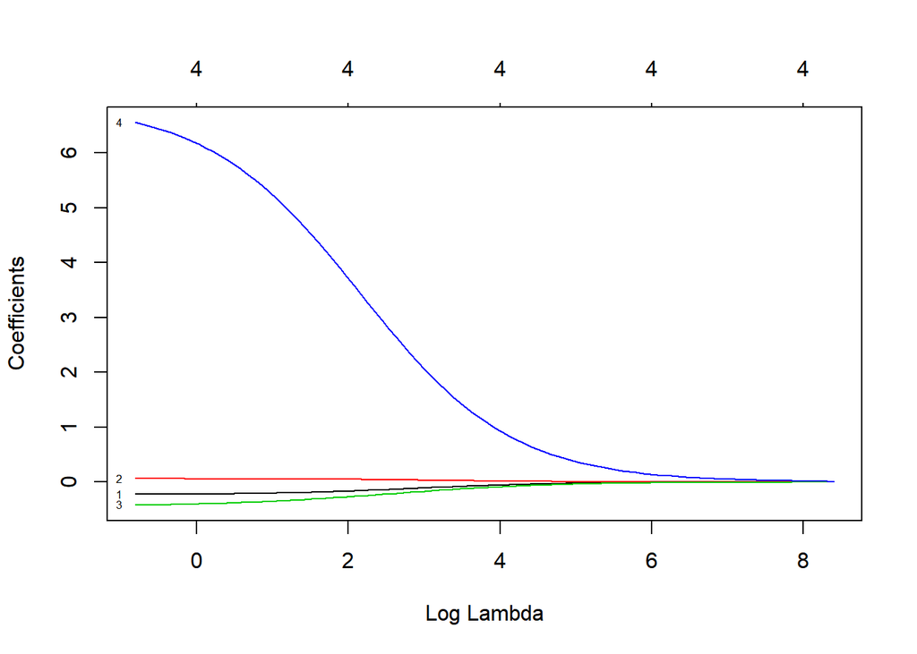

```r
plot(ridge.fit, xvar="lambda", label=TRUE)
```

$\lambda$가 작아질수록 설명된 deviation의 퍼센티지가 높아지는 사실을 확인할 수 있다. 또한 $\lambda$가 클수록, 즉 penalty가 강하게 부과될 수록, 회귀계수의 추정치들이 0으로 다가간다.  
obtaining best $\lambda$

```r
cv.glmnet(x=x, y=y, alpha=0, type.measure="mse", nfolds=20) -> ridge.fit.cv
ridge.fit.cv$lambda.min
```

```
## [1] 0.4877803
```

20개의 폴드를 통해 얻을 수 있는 최적의 값을 구하고, 이를 통한 계수들을 구해본다.

```r
coef(ridge.fit.cv, s="lambda.min")
```

```
## 5 x 1 sparse Matrix of class "dgCMatrix"
##                       1
## (Intercept) 26.87878414
## crim        -0.22427102
## zn           0.05966129
## indus       -0.41884837
## chas         6.52137556
```

```r
predict(ridge.fit.cv, newx=x, s="lambda.min")
```

```
##                 1
##   [1,] 26.9837301
##   [2,] 23.9114013
##   [3,] 23.9114058
##   [4,] 25.9584350
##   [5,] 25.9502088
##   [6,] 25.9590002
##   [7,] 24.3084126
##   [8,] 24.2957951
##   [9,] 24.2808385
##  [10,] 24.2900785
##  [11,] 24.2777772
##  [12,] 24.3018684
##  [13,] 24.3071814
##  [14,] 23.3281215
```

[output cut: 492 more lines]

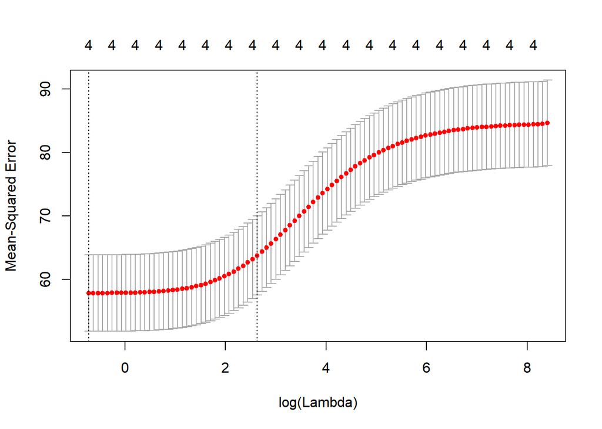

```r
plot(ridge.fit.cv)
```

람다를 통해 구한 계수들의 fitted value를 구해보고, 이 람다에서 에러가 최소화됨을 확인할 있다.

lasso regression을 수행하는 함수는 `glmnet(alpha=1)`

```r
glmnet(x=x, y=y, alpha=1) -> lasso.fit
lasso.fit
```

```
##
## Call:  glmnet(x = x, y = y, alpha = 1)
##
##       Df    %Dev  Lambda
##  [1,]  0 0.00000 4.44400
##  [2,]  1 0.03973 4.05000
##  [3,]  1 0.07271 3.69000
##  [4,]  1 0.10010 3.36200
##  [5,]  1 0.12280 3.06300
##  [6,]  2 0.14680 2.79100
##  [7,]  2 0.16900 2.54300
##  [8,]  2 0.18750 2.31700
##  [9,]  2 0.20290 2.11100
## [10,]  3 0.21730 1.92400
## [11,]  3 0.23030 1.75300
```

[output cut: 48 more lines]

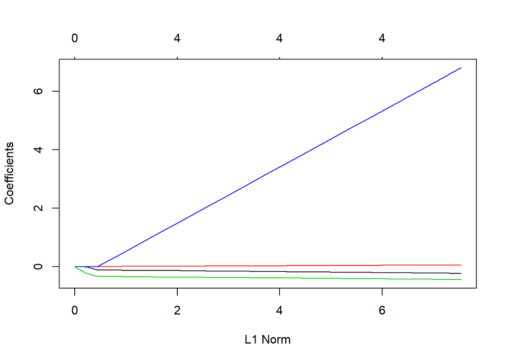

```r
plot(lasso.fit)
```

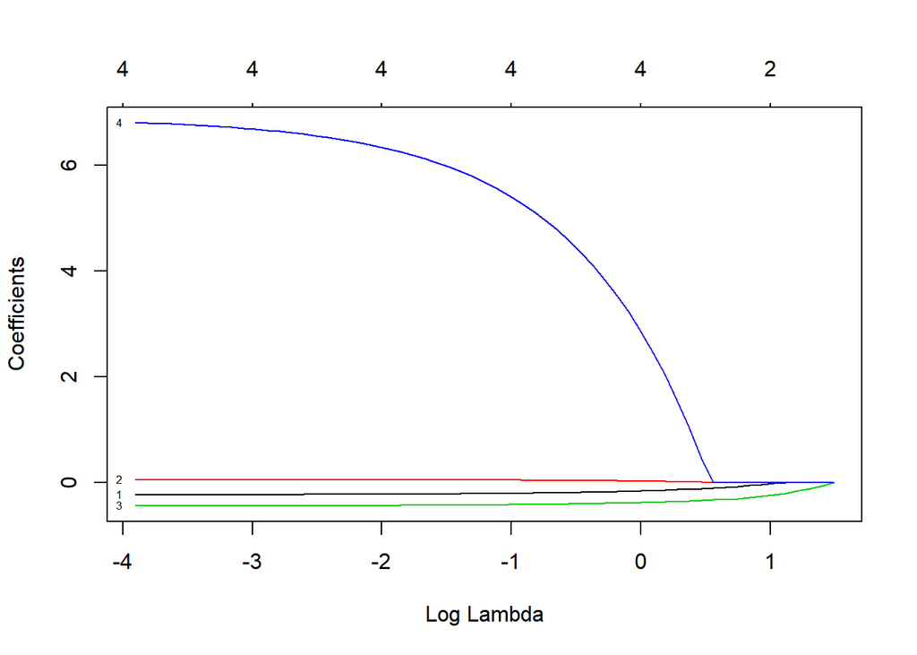

```r
plot(lasso.fit, xvar="lambda", label=TRUE)
```

$\lambda$가 커지고 페널티가 강하게 부과될수록 따라 0으로 수렴하는 회귀계수들이 많아 Sparse해진다.

obtaining best $\lambda$  
lasso regression 역시 k-folds cross validation을 통해 test error을 최소화하는 람다를 구하고, 이를 통한 회귀계수 추정치와 fitted value, 그리고 최소화된 error을 확인할 수 있다.

```r
lasso.fit.cv <- cv.glmnet(x=x, y=y, alpha=1, type.measure="mse", nfolds=20)
lasso.fit.cv$lambda.min
```

```
## [1] 0.02427694
```

```r
coef(lasso.fit.cv, s="lambda.min")
```

```
## 5 x 1 sparse Matrix of class "dgCMatrix"
##                       1
## (Intercept) 27.10494880
## crim        -0.22696704
## zn           0.05853951
## indus       -0.43884507
## chas         6.79640452
```

```r
predict(lasso.fit.cv, newx=x, s="lambda.min")
```

```
##                1
##   [1,] 27.143493
##   [2,] 23.996116
##   [3,] 23.996120
##   [4,] 26.140920
##   [5,] 26.132594
##   [6,] 26.141492
##   [7,] 24.362943
##   [8,] 24.350174
##   [9,] 24.335037
##  [10,] 24.344388
##  [11,] 24.331939
##  [12,] 24.356320
##  [13,] 24.361697
##  [14,] 23.389815
```

[output cut: 492 more lines]

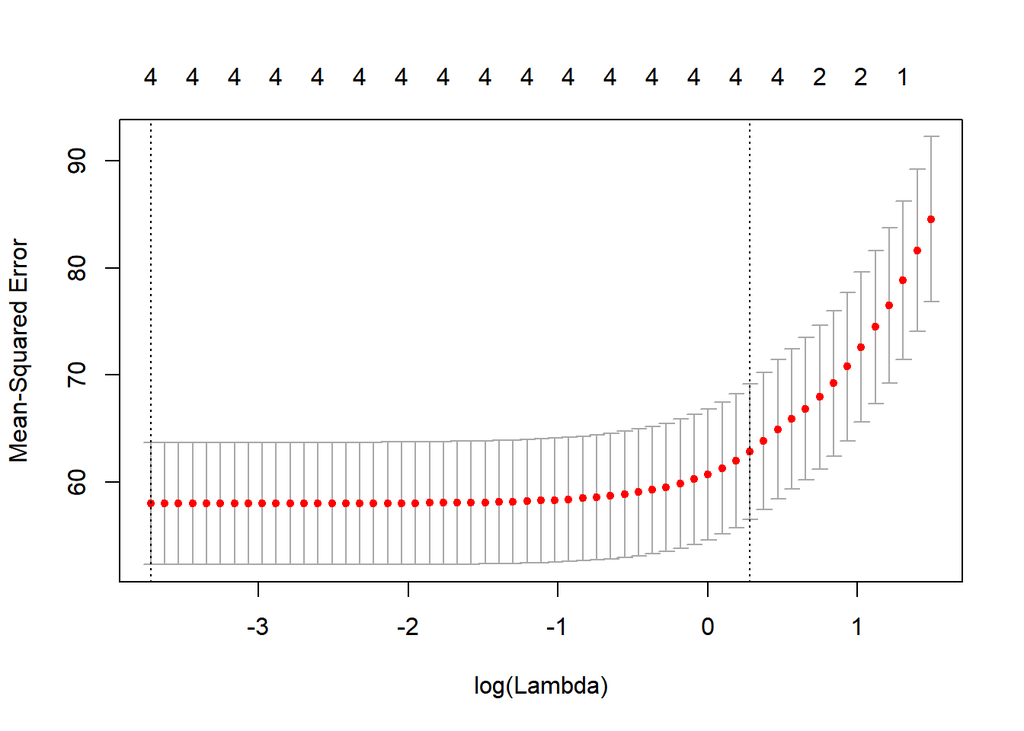

```r
plot(lasso.fit.cv)
```

성능 비교

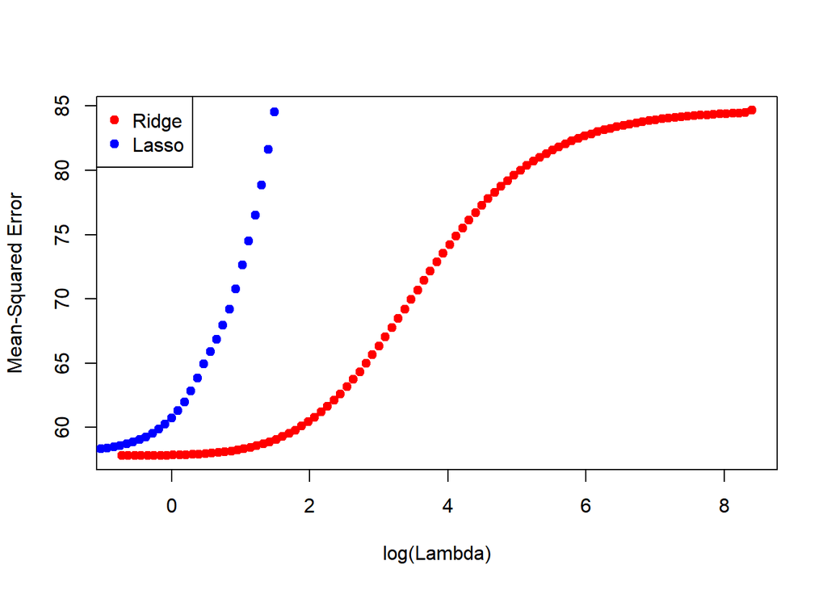

```r
plot(log(ridge.fit.cv$lambda), ridge.fit.cv$cvm, pch=19, col="red", xlab="log(Lambda)", ylab=ridge.fit.cv$name)
points(log(lasso.fit.cv$lambda), lasso.fit.cv$cvm, pch=19,col="blue")
legend("topleft",legend=c("Ridge", "Lasso"), pch=19, col=c("red", "blue"))
```